# Fastest 100 metre times

OCTAVIO E LIMA & PETROS BELAY

21 May 2021

## Background

In class, we practiced webscraping with the Wikipedia page on the [Men’s 100 metres world record progression](http://en.wikipedia.org/wiki/Men%27s_100_metres_world_record_progression). For this assignment, we’re going to continue with a similar theme, except we won’t only be limiting ourselves to world record times. The page that we’re scraping will also have a few complications that require extra (or at least different) steps.

Here is the webpage: **[All-time men’s best 100m](http://www.alltime-athletics.com/m_100ok.htm)**.

**Note:** You are welcome to use the [women’s all-time best 100m times](http://www.alltime-athletics.com/w_100ok.htm) if you prefer. However, please be aware that you may (will?) have to adjust some of the specific hints below. It will be become more obvious why once we get to the prediction section of the assignment.

Now is good time to load any packages that you will be needing, as well as set your preferred plotting theme, etc.

```r
## Load your packages here, e.g.
if (!require("pacman")) install.packages("pacman")
pacman::p_load(tidyverse, httr, lubridate, hrbrthemes, janitor, jsonlite, fredr,
               listviewer, usethis, rvest, ggthemes, stargazer, fastDummies,
               rnaturalearth, countrycode, sp, rnaturalearthdata, rnaturalearth,
               leaflet,tidygeocoder)
```

## 1) Read in the data

Take a look at the [webpage](http://www.alltime-athletics.com/m_100ok.htm) in your browser. We only want the information contained in the main table at the top (i.e. ignore the rolling starts, manual timing, etc.) Read this table into R and call the resulting object `m100_wp`.

*Hint: In class, we practiced identifying the correct HMTL elements with CSS selectors and SelectorGadget. However, you will almost certainly find it easier / more precise to scrape the table in this example via its XPath. Use your browser’s “Inspect” functionality to find and copy over this XPath. Remember to specify the “xpath” argument (instead of the default “css”) when pulling this information into R, i.e. `rvest::html_element(xpath = "XPATH_HERE")`.*

```r
# Using read_html and html_text from rvest package
m100_wp <- read_html("http://www.alltime-athletics.com/m_100ok.htm",
                     xpath = "/html/body/center[3]/pre/text()[8]") %>%

  html_nodes('pre')
```

## 2) Parse into an R object

### 2.1) Try parsing with `rvest::html_table()`

With the Wikipedia example from class, we were able to parse an HTML table into a data frame simply by using `rvest::html_table()`. What happens if you try that here?

**Parsing the scraped data using html_table() does not work because we are not scraping data from an HTML table. And so another function must be used to scrape the appropriate way (i.e., there are several functions to use for scraping several types of HTML elements)**

```r
m100_wp <- rvest::html_table(m100_wp)
```

```
## Error in matrix(unlist(values), ncol = width, byrow = TRUE): 'data' must be of a vector type, was 'NULL'
```

```r
# Error in matrix(unlist(values), ncol = width, byrow = TRUE) : 'data' must be of a vector type, was 'NULL'
```

### 2.2. Try parsing with `rvest::html_text()`

Unfortunately, the HTML object that we’ve read into R is old-school text. Luckily, we can still extract this text pretty easily into an R string. Do that and name the resulting object `m100_text`. Show me the first 1000 characters.

*Hint: The `head()` function works by elements, not characters. So you’ll need some other function to show the first 1000 characters.*

```r
m100_text <- rvest::html_text(m100_wp)
substr(m100_text, 1, 1000)
```

```
## [1] "\n        1      9.58       +0.9    Usain Bolt                     JAM     21.08.86    1      Berlin                        16.08.2009\n        2      9.63       +1.5    Usain Bolt                     JAM     21.08.86    1      London                        05.08.2012\n        3      9.69   …
## [2] "\n        1      9.91       +1.2    Dennis Mitchell                    USA     20.02.66    3      Tokyo                        25.08.1991\n        2      9.94       +0.1    Maurice Greene                     USA     23.07.74    1rA    Berlin                       01.09.1998\n        3      9…
## [3] "\n        1      9.7        -0.4    Souhalia Alamou                    BEN     31.12.79    1      Cotonou                      14.05.2004\n        2      9.9                Adama Fall                         SEN     25.12.50    1      Dakar                        05.04.1974\n        2      9…
## [4] "\n        1      9.7        +1.9    Donovan Powell                 JAM     31.10.71    1      Houston                       19.05.1995\n        1      9.7        +1.9    Carl Lewis                     USA     01.07.61    2      Houston                       19.05.1995\n        1      9.7    …
## [5] "\n        1      10.05              Frank Fredericks                   NAM     02.10.67    1      Tampere                       12.02.1996\n\n"
## [6] "\n        1      9.91       +0.1    Usain Bolt                     JAM     21.08.86    1rA    Manchester              17.05.2009\n        2      9.92       -0.3    Usain Bolt                     JAM     21.08.86    1      Berlin                  20.08.2009\n        3      9.96       -0.9    …
## [7] "\n        1      9.88               Maurice Greene                     USA     23.07.74    1q2    Edmonton                     04.08.2001\n        3      9.95               Bernard Williams                   USA     19.01.78    1q5    Edmonton                     04.08.2001\n        4      9…
```

## 3) Convert to a data frame

## 3.1 ) Read as data frame

At this point, we basically have one loooong string that we need to convert to a data frame. Please do this and assign the resulting object as `m100`. Don’t worry about specifying column names yet.

*Hint: You have two (related) options here: Convert either based on whitespace separation of columns, or fixed-width file format. The `readr` package provides methods for reading both whitespace-separated columns and fixed-width files. See the [reference guide](https://readr.tidyverse.org/reference/index.html#section-read-rectangular-files) guide for more details. If you opt for the latter, please pay particular attention to the option of guessing the fixed column positions based on the the position of empty columns, as well as how many rows are parsed by default to determine the data frame shape. See the Details and Examples sections of the relevant help documentation.*

```r
# Convert scraped text into dataframe
m100 = readr::read_table(m100_text, col_names = F)
m100 = head(m100, 3436)
```

## 3.2) Inspect and fix (if needed)

What does your resulting `m100` data frame look like? Print the first and last few rows to screen so that I can see it too.

Depending on the functions and arguments that you used in the previous question, you may need to do some additional work to fix the resulting data frame, For example, you should only have 9 columns. If that isn’t the case, inspect your dataset and figure out where the problem lies. Fix this issue as best you can, so that you only have nine columns.

*Hint: Look for an athlete that has the first name “Kareem” for an illustration of what might go wrong.*

**The data scraped from the website has been formatted nicely into a dataframe, although the column names may need to be changed, variable types need to be converted for analysis and some cleaning on a few columns should be done (e.g., removing the positive signs from windspeed and fixing the periods on date for lubridate to read).**

```r
# First and last 10 rows of dataframe
head(m100, n = 10)
```

| X1 | X2 | X3 | X4 | X5 | X6 | X7 | X8 | X9 |
| --- | --- | --- | --- | --- | --- | --- | --- | --- |
| 1 | 9.58 | +0.9 | Usain Bolt | JAM | 21.08.86 | 1 | Berlin | 16.08.2009 |
| 2 | 9.63 | +1.5 | Usain Bolt | JAM | 21.08.86 | 1 | London | 05.08.2012 |
| 3 | 9.69 | ±0.0 | Usain Bolt | JAM | 21.08.86 | 1 | Beijing | 16.08.2008 |
| 3 | 9.69 | +2.0 | Tyson Gay | USA | 09.08.82 | 1 | Shanghai | 20.09.2009 |
| 3 | 9.69 | -0.1 | Yohan Blake | JAM | 26.12.89 | 1 | Lausanne | 23.08.2012 |
| 6 | 9.71 | +0.9 | Tyson Gay | USA | 09.08.82 | 2 | Berlin | 16.08.2009 |
| 7 | 9.72 | +1.7 | Usain Bolt | JAM | 21.08.86 | 1rA | New York City | 31.05.2008 |
| 7 | 9.72 | +0.2 | Asafa Powell | JAM | 23.11.82 | 1rA | Lausanne | 02.09.2008 |
| 9 | 9.74 | +1.7 | Asafa Powell | JAM | 23.11.82 | 1h2 | Rieti | 09.09.2007 |
| 9 | 9.74 | +0.9 | Justin Gatlin | USA | 10.02.82 | 1 | Ad-Dawhah | 15.05.2015 |

```r
tail(m100, n = 10)
```

| X1 | X2 | X3 | X4 | X5 | X6 | X7 | X8 | X9 |
| --- | --- | --- | --- | --- | --- | --- | --- | --- |
| 308 | 10.09 | -0.1 | Yohan Blake | JAM | 26.12.89 | 2s2 | Ad-Dawhah | 28.09.2019 |
| 308 | 10.09 | -0.1 | Justin Gatlin | USA | 10.02.82 | 3s2 | Ad-Dawhah | 28.09.2019 |
| 308 | 10.09 | +0.1 | Deniz Almas | GER | 17.07.97 | 1 | Braunschweig | 08.08.2020 |
| 308 | 10.09 | +1.8 | Kenny Bednarek | USA | 14.10.98 | 2h1 | Montverde | 10.08.2020 |
| 308 | 10.09 | +1.6 | Justin Gatlin | USA | 10.02.82 | 2h2 | Montverde | 10.08.2020 |
| 308 | 10.09 | +0.7 | Yoshihide Kiryu | JPN | 15.12.95 | 1h3 | Tokyo | 23.08.2020 |
| 308 | 10.09 | +0.9 | Jeffery Demps | USA | 08.01.90 | 1r1 | Des Moines | 29.08.2020 |
| 308 | 10.09 | +0.3 | Filippo Tortu | ITA | 15.06.98 | 3 | Roma | 17.09.2020 |
| 308 | 10.09 | +1.9 | Marvin Bracy | USA | 15.12.93 | 6rA | Miramar | 10.04.2021 |
| 308 | 10.09 | +0.4 | Rohan Browning | AUS | 31.12.97 | 1 | Sydney | 17.04.2021 |

### 3.3) Assign column names

You should now (hopefully) have nine columns. Assign them the following names: `c("rank", "time", "windspeed", "athlete", "country", "dob", "race_rank", "location", "date")`.

```r
# Reassigning column names
m100 = m100 %>% rename("rank" = X1, "time" = X2, "windspeed" = X3, "athlete" = X4,
                       "country" = X5, "dob" = X6, "race_rank" = X7, "location" = X8,
                       "date" = X9)
```

### 3.4 Convert columns to correct classes

Finally, convert your columns to the correct classes. Date columns should be converted to dates, numeric columns should be converted to numeric, etc.

```r
# Some of the times were followed by an "A". So I'm removing these A's from all columns.
m100$time <- gsub("A", "", m100$time)

# Converting time from "character" to "numeric"
m100$time = as.numeric(m100$time)

m100$windspeed = as.numeric(m100$windspeed)

# as.numeric() turned "+-0.0" into NAs; so I'm converting them back to "0.0"
m100$windspeed[is.na(m100$windspeed)] <- 0

m100$dob = parse_date_time2(m100$dob, orders = "dmy")
# Used dmy() functionfrom Lubridate (included in Tidyverse)

m100$date = dmy(m100$date)
# m100$date = parse_date_time(m100$date, orders = c("ymd", "dmy", "mdy"))
```

## 4) Plot the data

Plot the data, with the race date on the x-axis and time on the y-axis. Highlight Usain Bolt’s times in red.

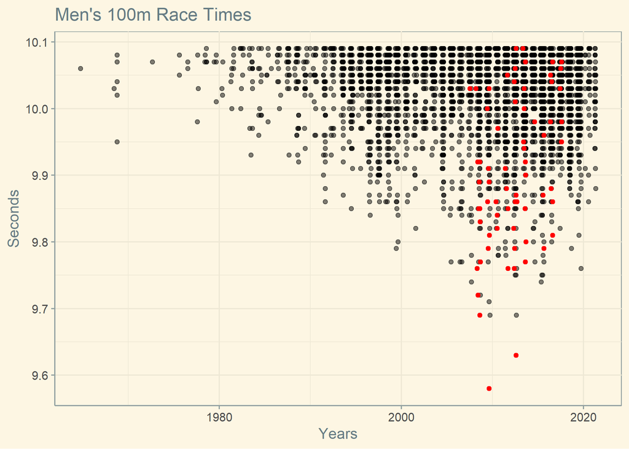

```r
# Filter what we want highlighted
usain = m100 %>% filter(athlete == "Usain Bolt")

plot = ggplot(data = m100, aes(x = date, y = time)) +
       geom_point(alpha = .5) + geom_point(data = usain, aes(x = date, y = time), color = 'red') +
       labs(x = "Years", y = "Seconds", title = "Men's 100m Race Times") + theme_solarized()

plot
```

## 5) Subset to fastest times per year

- It’s hard to fit a sensible model to the above data.
- What might make more sense is to think of 100 metre times as following some kind of (approximately) deterministic process over the years.
- Subset the data to the fastest time recorded in each year.
- Call this new data frame `m100_yr` and then repeat the plot above, again highlighting Usain Bolt’s times.

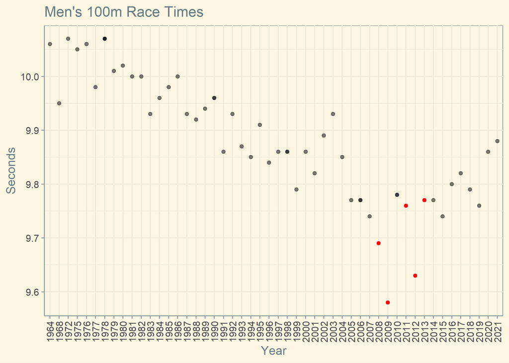

```r
m100_yr <- m100

# Retrieving only YYYY values rather than YYYY-MM-DD
m100_yr$date <- substr(m100$date, 1, 4)

# Subsetting the data
m100_yr <- m100_yr %>%
           group_by(date) %>%
           filter( time == min(time) ) %>%
           arrange( desc(date), .by_group = TRUE )

usain_yr = m100_yr %>% filter(athlete == "Usain Bolt")

plot2 = ggplot(data = m100_yr, aes(x = date, y = time)) +
        geom_point(alpha = .5) + geom_point(data = usain_yr, aes(x = date, y = time), color = 'red') +
        labs(x = "Year", y = "Seconds", title = "Men's 100m Race Times") + theme_solarized() +
        theme(axis.text.x = element_text(angle = 90, vjust = 0.5, hjust = 1))

plot2
```

## 6) Modeling and prediction

Imagine that you are back in the year **2005**. You are tasked with fitting a model of year-best 100m times up until that point. Importantly, your model will also be used to predict the trajectory of future 100m times.

### 6.1) Fit a model

- Start by fitting a simple regression model of your choice, using data that would have been available to you then (you can include 2005).
- You are free to use whatever specification you prefer, but please be explicit by writing the model down. (Use dollar signs to demarcate LaTeX equations in R Markdown.)
- Please also show me the actual regression results in a nicely-formatted table.

*Hint: I’d advise excluding data from before 1975, since we don’t have consecutive or consistent records before then.*

$$Y = \beta_0 + \beta_1 X_1 + \epsilon$$

```r
#change date and time to numeric
m100_yr$time = as.numeric(m100_yr$time)
m100_yr$date = as.numeric(m100_yr$date)


# Data up until 2005
# m100_yr_05 <- head(m100_yr, 38)
m100_yr_05 <- m100_yr %>% filter(date <= 2005 && date > 1975)

#change to date
# m100_yr_05$X9 = lubridate::dmy(m100_yr_05$X9)

# Simple Linear Model | running time (y) on date (x)
linear_model <- lm(time ~ date, m100_yr_05)

stargazer(linear_model, type = "text")
```

```
##
## ===============================================
##                         Dependent variable:
##                     ---------------------------
##                                time
## -----------------------------------------------
## date                         -0.008***
##                               (0.001)
##
## Constant                     26.090***
##                               (1.528)
##
## -----------------------------------------------
## Observations                    34
## R2                             0.778
## Adjusted R2                    0.771
## Residual Std. Error       0.039 (df = 32)
## F Statistic           111.860*** (df = 1; 32)
## ===============================================
## Note:               *p<0.1; **p<0.05; ***p<0.01
```

### 6.2) Prediction

Fast forward to the present day. Given your model and the available data in 2005, what year would you have predicted humanity reaching the current world record time of 9.58 seconds? How does this compare with the year that Usain Bolt actually set it (i.e. 2009). What do you make of this?

**According to our model, we would reach a time of 9.58 seconds in the year 2033 (about 24 years off the actual year). This is obviously some years away from the year it was actually set (2009) but is also not a very bad prediction considering this is a very simple model with only one explanatory variable and a small sample size.**

```r
new_data <- m100_yr %>% filter(date > 2005)

new_date <- data.frame(
  date <- c(new_data$date)
)

# 1. Add predictions
predicted <- predict(linear_model, new_date, interval = "confidence")
predicted

mydata2 <- cbind(date = new_data$date, time = new_data$time, predicted)
mydata2 <- as.data.frame(mydata2)
```

[output not shown]

### 6.3) Plot your results

Provide a visual depiction of your prediction model. I basically want you to repeat your earlier plot from Question 4, but now with a (95 percent) prediction envelope. The prediction envelope should extend through both the “fitted” (<= 2005) *and* “predicted” (2006–present) data periods. Make sure that these two periods are clearly demarcated in your plot.

*Hint: geom_smooth() isn’t going to help you here because you need to predict out of sample.*

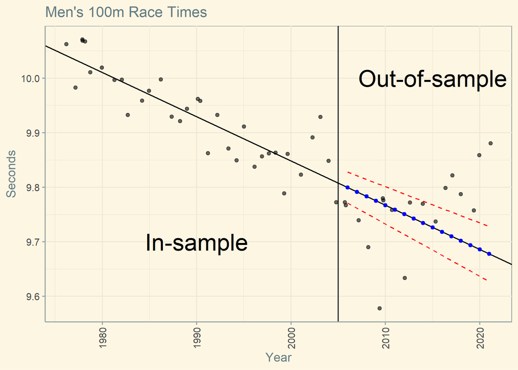

```r
#removing dates before 1975
m100_yr = m100_yr %>% filter(date > 1975)

plot6 <- ggplot(m100_yr) + aes(x = date, y = time) +
  geom_point(alpha = 0.6, position = "jitter") +
  geom_abline(intercept = linear_model$coefficients[1],
              slope = linear_model$coefficients[2]) +
  geom_vline(xintercept = 2005) +
  annotate("text",x = 2015, y = 10, label = "Out-of-sample", size = 8) +
  annotate("text", x = 1990, y = 9.7, label = "In-sample", size = 8) +
  labs(x = "Year", y = "Seconds", title = "Men's 100m Race Times") +
  theme_solarized() +
  theme(axis.text.x = element_text(angle = 90, vjust = 0.5, hjust = 1)) +
  geom_point(data = mydata2, aes(date, fit), color = "blue") +
  geom_line(data = mydata2, aes(y = lwr), color = "red", linetype = "dashed") +
  geom_line(data = mydata2, aes(y = upr), color = "red", linetype = "dashed")

plot6
```

## 7) Map

### 7.1 Static map

Finally, go back to your original `m100` data frame, which contains all the data (i.e. not just the fastest time in each year). I want you to give me a sense of athletic achievement by country (including duplicate observations for the same athlete). Plot a world map, with a colour fill proportional to the number of fastest times that have been contributed by athletes of each country.

*Hint: Use the `sf`-compatible “countries” data frame from the `rnaturalearth` package that I showed you in the spatial lecture. This will come with a column of “iso_a3” country codes that you can match (i.e. join) to the “country” column of the `m100` data frame. There will likely be some mismatches because of inconsistencies in the ISO codes across these data frames. I won’t be too strict about this, though you may find the `countrycode::countrycode()` function a helpful alternative.*

```r
# Converted Country Codes into Country Names using countrycode and tibble
country_names <- countrycode::countrycode(m100$country, origin = 'iso3c', destination = 'country.name')
```

```r
m100 <- tibble::add_column(m100, country_names, .after = "country")
# head(m100)

# # Removing NAs from m100
m100 <- na.omit(m100)


# World Map below still needs to be fixed/debugged
WorldData <- map_data('world') %>% filter(region != "Antarctica") %>% fortify

df <- data.frame(country = m100$country_names,
                 time = m100$time,
                 stringsAsFactors = FALSE)


# Checking to see how many countries in this dataset; renaming some countries to "match" WorldData
df <- count( df, country )
df[30, 1] <- "USA"
df[29, 1] <- "UK"
df[26, 1] <- "Trinidad"
df[ 6, 1] <- "Ivory Coast"

#         country    n
# 1     Australia   13
# 2    Azerbaijan    1
# 3        Brazil   13
# 4        Canada  131
# 5         China   38
# 6   Ivory Coast   34
# 7          Cuba   17
# 8       Ecuador    2
# 9        France  100
# 10        Ghana   38
# 11      Hungary    2
# 12        Italy   13
# 13      Jamaica  625
# 14        Japan   65
# 15   Kazakhstan    2
# 16      Liberia    2
# 17      Morocco    1
# 18      Namibia   62
# 19       Norway   17
# 20       Panama    5
# 21       Poland    1
# 22        Qatar   23
# 23 Sierra Leone    1
# 24  South Korea    1
# 25        Spain    2
# 26     Trinidad  182
# 27       Turkey   24
# 28      Ukraine    2
# 29           UK  219
# 30          USA 1331

# previous dataset but without the US.
df1 <- df[1:29,]
```

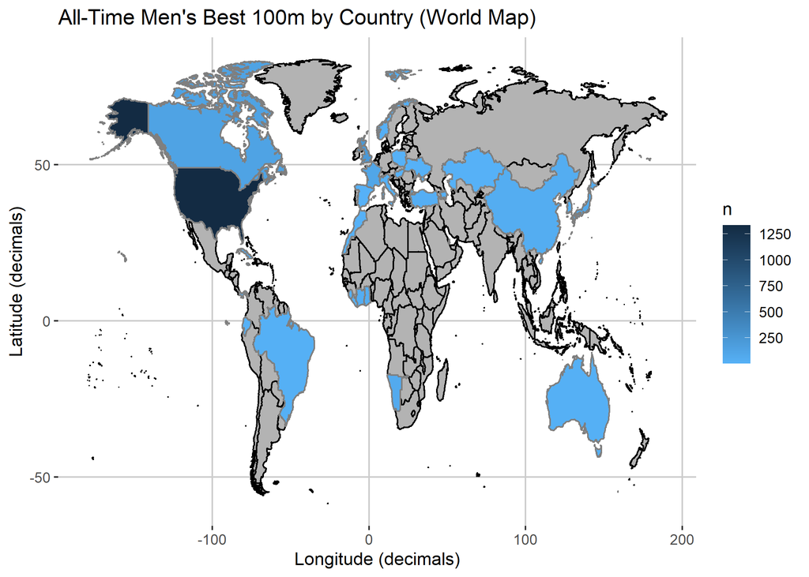

```r
# World Map

mapa <- borders("world", regions = unique(WorldData$region),
                fill = "grey70", colour = "black")

ggplot() +
            mapa +
            geom_map(data = df, map = WorldData,
               aes(fill = n, map_id = country),
               colour = "#7f7f7f", size = 0.5) +
            theme_bw() +
            xlab("Longitude (decimals)") +
            ylab("Latitude (decimals)") +
            ggtitle("All-Time Men's Best 100m by Country (World Map)") +
            theme(panel.border = element_blank(), panel.grid.major = element_line(colour = "grey80"), panel.grid.minor = element_blank()) +
            scale_fill_continuous(high = "#132B43", low = "#56B1F7")
```

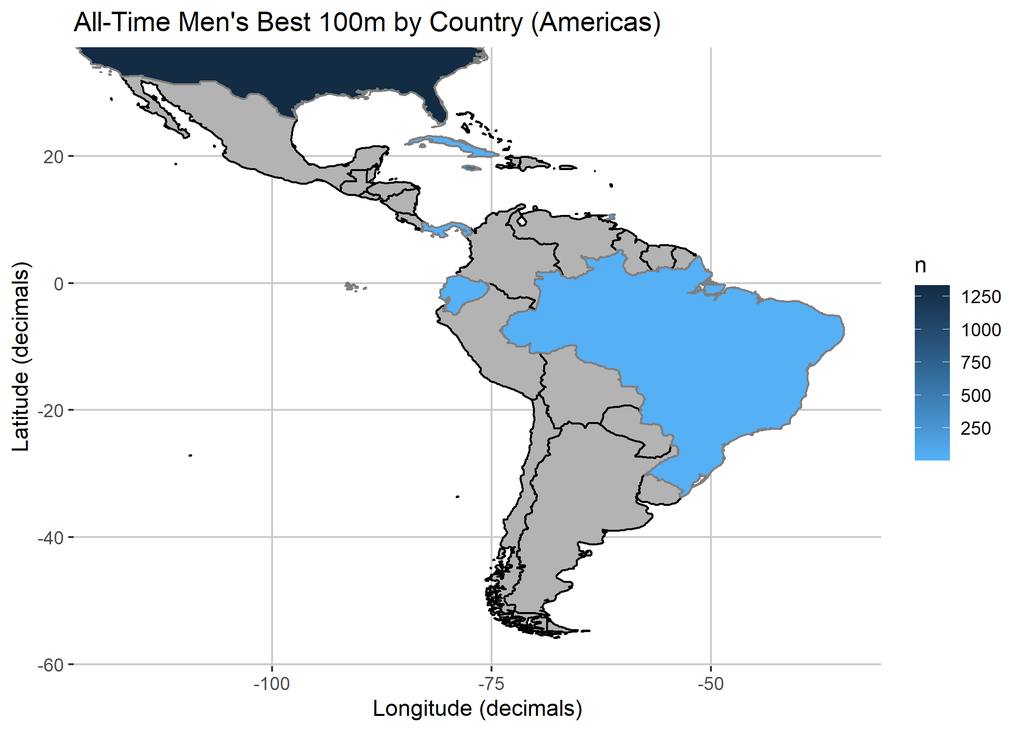

```r
# Map of the Americas

mapa <- borders("world", regions = c("Brazil", "Uruguay", "Argentina", "French Guiana", "Suriname", "Colombia", "Venezuela",
                                     "Bolivia", "Ecuador", "Chile", "Paraguay", "Peru", "Guyana", "Panama", "Costa Rica",
                                     "Nicaragua", "Honduras", "El Salvador", "Belize", "Guatemala", "Mexico", "Trinidad and Tobago",
                                     "Caribe", "Puerto Rico", "Dominican Republic", "Haiti", "Jamaica", "Cuba", "Bahamas", "Antiles",
                                     "Dominica", "Saba"),
                fill = "grey70", colour = "black")

ggplot() +
  mapa +
  geom_map(data = df, map = WorldData,
           aes(fill = n, map_id = country),
           colour = "#7f7f7f", size = 0.5) +
  theme_bw() +
  xlab("Longitude (decimals)") +
  ylab("Latitude (decimals)") +
  ggtitle("All-Time Men's Best 100m by Country (Americas)") +
  theme(panel.border = element_blank(), panel.grid.major = element_line(colour = "grey80"), panel.grid.minor = element_blank()) +
  scale_fill_continuous(high = "#132B43", low = "#56B1F7")
```

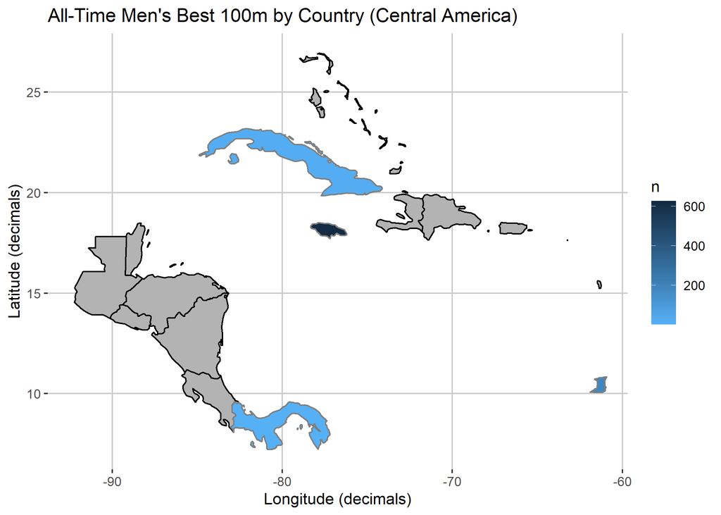

```r
# Central America

mapa <- borders("world", regions = c("Panama", "Costa Rica",
                                     "Nicaragua", "Honduras", "El Salvador", "Belize", "Guatemala", "Trinidad and Tobago",
                                     "Caribe", "Puerto Rico", "Dominican Republic", "Haiti", "Jamaica", "Cuba", "Bahamas", "Antiles",
                                     "Dominica", "Saba"),
                fill = "grey70", colour = "black")

ggplot() +
  mapa +
  geom_map(data = df1, map = WorldData,
           aes(fill = n, map_id = country),
           colour = "#7f7f7f", size = 0.5) +
  theme_bw() +
  xlab("Longitude (decimals)") +
  ylab("Latitude (decimals)") +
  ggtitle("All-Time Men's Best 100m by Country (Central America)") +
  theme(panel.border = element_blank(), panel.grid.major = element_line(colour = "grey80"), panel.grid.minor = element_blank()) +
  scale_fill_continuous(high = "#132B43", low = "#56B1F7")
```

### 7.2. Interactive map

A major downside of the above static map is that some powerhouses of world athletics are geographically tiny nations in the Caribbean, which are very hard to see. One way to overcome this is to plot an interactive map using **leaflet** or one of the derivative packages that we discussed in the spatial lecture.

**We are not sure why, but it seems the addMarkers() function is not rendering our data points correctly. The idea was to set a marker at each lat/long of our countries in the data frame below, with a popup of the number of best times above the marker. We got the markers to render just once, but for a reason we could not figure out the addMarkers() function is not rendering. We have attached an enlarged map of the Caribbean above to view the countries which may have been to small to view on the world map.**

```r
#dataframe with lat/long columns
leaflet_data = geocode(df,country="country")
#adding trinidad's lat/long (geocode didnt get it)
leaflet_data[26,][3] = 10.375722
leaflet_data[26,][4] = -61.233559

leaflet_data
```

| country | n | lat | long |
| --- | --- | --- | --- |
| Australia | 13 | -24.776109 | 134.755000 |
| Azerbaijan | 1 | 40.393629 | 47.787251 |
| Brazil | 13 | -10.333333 | -53.200000 |
| Canada | 131 | 61.066692 | -107.991707 |
| China | 38 | 35.000074 | 104.999927 |
| Ivory Coast | 34 | 7.989737 | -5.567946 |
| Cuba | 17 | 23.013134 | -80.832875 |
| Ecuador | 2 | -1.339767 | -79.366697 |
| France | 100 | 46.603354 | 1.888334 |
| Ghana | 38 | 7.857371 | -1.084098 |

[output cut: 20 more lines]

```r
#leaflet map
l <- leaflet(data = leaflet_data, width = 580, height = 500) %>%
  setView(lng = -443.800174, lat = 19.547561, zoom = 4.5) %>%
  addTiles() %>%
  addMarkers(lng = leaflet_data$long, lat = leaflet_data$lat,
             popup = as.character(leaflet_data$n),
             label = as.character(leaflet_data$n),
             data = leaflet_data)

l
```

[interactive chart not shown]